# Manuscript_fishing_hours

Théophile L. Mouton

2026-10-07

## Open R libraries

```r
library(tidyverse)
library(tidyr)
library(ggplot2)
library(data.table)
library(gridExtra)
library(maps)
library(raster)
library(sf)
library(viridis)
library(scales)
library(dplyr)
library(randomForest)
library(caret)
library(pdp)
library(knitr)
library(kableExtra)
library(future)
library(spdep)
library(ncf)
library(blockCV)
library(parallel)
library(doParallel)
library(sp)
library(purrr)
library(kableExtra)
library(webshot2)
```

## Open datasets

```r
#AIS data
load(here::here("R","Data","AIS_fishing.Rdata"))

#SAR data
load(here::here("R","Data","SAR_fishing.Rdata"))

# Load overpass frequency data
load(here::here("R", "Data", "SAR_overpasses_per_cell.Rdata"))

# Open the saved adjusted rasters
Ports_adjusted <- raster(here::here("R", "Data", "distance-from-port-0.1deg-adjusted.tif"))
Shore_adjusted <- raster(here::here("R", "Data", "distance-from-shore-0.1deg-adjusted.tif"))
Bathy_adjusted <- raster(here::here("R", "Data", "bathymetry-0.1deg-adjusted.tif"))

# Load combined AIS and SAR data
load(here::here("R", "Data","combined_data_O1deg.Rdata"))

# High seas mask, used to remove high-seas cells from the fishing maps
# (the high seas are not included in the analyses of fishing effort)
High_seas <- st_read(here::here("R", "Data", "World_High_Seas_v2_20241010", "High_Seas_v2.shp"), quiet = TRUE)
high_seas_raster <- terra::rasterize(terra::vect(High_seas),
                                     terra::rast(xmin = -180, xmax = 180, ymin = -90, ymax = 90, resolution = 0.1),
                                     field = 1)

# Removes 0.1-degree cells whose centre falls within the high seas
# (lon_std and lat_std are the lower-left corners of the cells)
remove_high_seas <- function(df) {
  xy <- cbind(df$lon_std + 0.05, df$lat_std + 0.05)
  in_high_seas <- terra::values(high_seas_raster)[terra::cellFromXY(high_seas_raster, xy), 1]
  df[is.na(in_high_seas), ]
}

# McBryde-Thomas 2 projection, as in the main text maps
mcbryde_thomas_2 <- "+proj=mbt_s"

land_projected <- rnaturalearth::ne_countries(scale = "medium", returnclass = "sf") %>%
  st_transform(crs = mcbryde_thomas_2)

globe_border <- st_polygon(list(rbind(c(-180, -90), c(-180, 90), c(180, 90), c(180, -90), c(-180, -90)))) %>%
  st_sfc(crs = 4326) %>%
  smoothr::densify(max_distance = 0.5) %>%
  st_transform(crs = mcbryde_thomas_2)

# Projects 0.1-degree cells (lon_std/lat_std = lower-left corners) to McBryde-Thomas 2,
# as for the grid cells in Fig. 2 (point transformation, no raster reprojection).
# Each cell is drawn as its projected outline: in this pseudocylindrical projection,
# y depends only on latitude and x is linear in longitude along a parallel, so the
# projected cells tile the map exactly, without gaps or overlaps
project_tiles <- function(df, value_col) {
  df <- df[!is.na(df[[value_col]]), ]
  lon <- df$lon_std
  lat <- df$lat_std
  lonlat <- "+proj=longlat +datum=WGS84 +no_defs"
  west  <- sf::sf_project(lonlat, mcbryde_thomas_2, cbind(lon,        lat + 0.05))
  east  <- sf::sf_project(lonlat, mcbryde_thomas_2, cbind(lon + 0.1,  lat + 0.05))
  south <- sf::sf_project(lonlat, mcbryde_thomas_2, cbind(lon + 0.05, lat))
  north <- sf::sf_project(lonlat, mcbryde_thomas_2, cbind(lon + 0.05, pmin(lat + 0.1, 90)))
  out <- data.frame(xmin = west[, 1], xmax = east[, 1], ymin = south[, 2], ymax = north[, 2])
  out[[value_col]] <- df[[value_col]]
  out[is.finite(out$xmin) & is.finite(out$xmax) & is.finite(out$ymin) & is.finite(out$ymax), ]
}

# Join overpass frequency data and compute normalised detections
combined_data_01deg <- combined_data_01deg %>%
  left_join(
    overpasses_per_cell %>% dplyr::select(lon_std, lat_std, n_overpasses, detections_per_overpass),
    by = c("lon_std", "lat_std")
  )

# Load saved models (comment out training blocks above after first run)
rf_norm_no_transform <- readRDS(here::here("R", "Data", "rf_norm_no_transform.rds"))
rf_norm_fishing_log <- readRDS(here::here("R", "Data", "rf_norm_fishing_log.rds"))
rf_norm_predictor_log <- readRDS(here::here("R", "Data", "rf_norm_predictor_log.rds"))
rf_norm_both_log <- readRDS(here::here("R", "Data", "rf_norm_both_log.rds"))

# Function to evaluate models
evaluate_model <- function(model, data, log_target = FALSE) {
  predictions <- predict(model, newdata = data)
  if (log_target) {
    predictions <- 10^predictions - 1
  }

  actual <- if (log_target) 10^data$log_total_fishing_hours - 1 else data$total_fishing_hours

  # Basic Error Metrics
  mae <- mean(abs(actual - predictions), na.rm = TRUE)
  rmse <- sqrt(mean((actual - predictions)^2, na.rm = TRUE))
  mape <- mean(abs((actual - predictions) / actual) * 100, na.rm = TRUE)
  medae <- median(abs(actual - predictions), na.rm = TRUE)

  # R-squared (matching randomForest's % Var explained)
  r_squared <- model$rsq[length(model$rsq)]

  # Adjusted R-squared
  n <- length(actual)
  p <- length(model$forest$independent.variable.names) # Number of predictors
  adj_r_squared <- 1 - ((1 - r_squared) * (n - 1) / (n - p - 1))

  # Residual Analysis
  residuals <- actual - predictions
  mean_residual <- mean(residuals, na.rm = TRUE)
  sd_residual <- sd(residuals, na.rm = TRUE)

  # Feature Importance (for Random Forest)
  feature_importance <- importance(model)

  return(list(
    "Mean absolute error" = mae,
    "Root mean squared error" = rmse,
    "Mean absolute percentage error" = mape,
    "Median absolute error" = medae,
    "R-squared" = r_squared,
    "Adjusted R-squared" = adj_r_squared,
    "Mean of residuals" = mean_residual,
    "Standard deviation of residuals" = sd_residual,
    "Feature importance" = feature_importance
  ))
}
```

## AIS data

Data from Kroodsma et al. (2018) Science, accessible at: [Global Fishing Watch Data Download Portal](https://globalfishingwatch.org/data-download/datasets/public-fishing-effort).

The data is accessible up to the end of the year 2020, we used four entire years of data (2017, 2018, 2019, 2020) to match SAR data records.

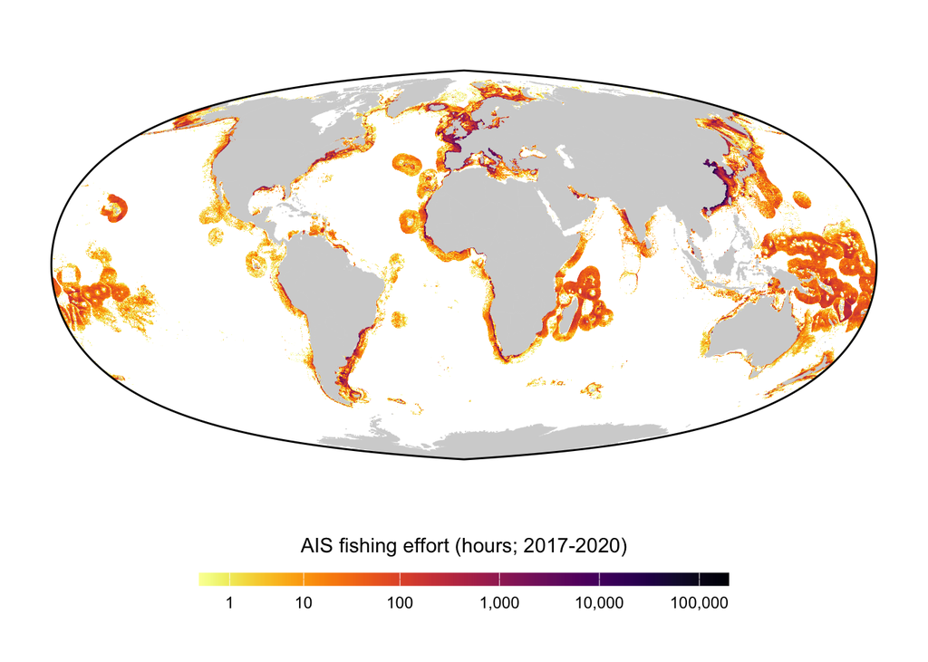

```r
# Set the path to the 2017-2020 folder

#path <- "R/Data/AIS Fishing Effort 2017-2020"

# List all CSV files in the folder
#AIS_csv_files <- list.files(path = here::here(path), pattern = "*.csv", full.names = TRUE, recursive = TRUE)

# Read all CSV files and combine them into a single data frame
#AIS_fishing <- AIS_csv_files %>%
#  map_df(~read_csv(.))

# Aggregate fishing hours by latitude and longitude
aggregated_AIS_fishing <- AIS_fishing %>%
  group_by(cell_ll_lat, cell_ll_lon) %>%
  summarise(total_fishing_hours = sum(fishing_hours, na.rm = TRUE)) %>%
  ungroup() %>%
  # Remove any cells with zero or negative fishing hours
  filter(total_fishing_hours > 0)

# Function to standardize coordinates to 0.1 degree resolution
standardize_coords <- function(lon, lat) {
  list(
    lon_std = floor(lon * 10) / 10,
    lat_std = floor(lat * 10) / 10
  )
}

# Standardize and aggregate AIS data
AIS_data_std <- aggregated_AIS_fishing %>%
  mutate(coords = map2(cell_ll_lon, cell_ll_lat, standardize_coords)) %>%
  mutate(
    lon_std = map_dbl(coords, ~ .x$lon_std),
    lat_std = map_dbl(coords, ~ .x$lat_std)
  ) %>%
  group_by(lon_std, lat_std) %>%
  summarise(total_fishing_hours = sum(total_fishing_hours, na.rm = TRUE), .groups = "drop")

# Create the world map
world_map <- map_data("world")

# Assign plot to variable
AIS_data_plot <- ggplot() +
  geom_rect(data = project_tiles(remove_high_seas(AIS_data_std), "total_fishing_hours"),
            aes(xmin = xmin, xmax = xmax, ymin = ymin, ymax = ymax, fill = total_fishing_hours)) +
  geom_sf(data = land_projected, fill = "lightgrey", color = "lightgrey", linewidth = 0.1) +
  geom_sf(data = globe_border, fill = NA, color = "black", linewidth = 0.5) +
  scale_fill_viridis(
    option = "inferno",
    direction = -1,
    trans = "log1p",
    name = "AIS fishing effort (hours; 2017-2020)",
    breaks = c(0, 1, 10, 100, 1000, 10000, 100000),
    labels = scales::comma,
    guide = guide_colorbar(barwidth = 20, barheight = 0.5, title.position = "top", title.hjust = 0.5)
  ) +
  coord_sf(crs = mcbryde_thomas_2, datum = NA) +
  theme_minimal() +
  labs(title = NULL,
       x = NULL, y = NULL) +
  theme(
    legend.position = "bottom",
    legend.direction = "horizontal",
    legend.box = "vertical",
    legend.margin = ggplot2::margin(t = 20, r = 0, b = 0, l = 0),
    legend.title = element_text(margin = ggplot2::margin(b = 10))
  )

print(AIS_data_plot)
```

```r
# Save the plot
ggsave(here::here("R","Outputs","AIS_fishing_map.png"),
       plot = AIS_data_plot,
       width = 12,
       height = 8,
       dpi = 300)
```

## Sentinel-1 SAR data

Data from Paolo et al. 2024 Nature, accessible at: [Global Fishing Watch SAR Vessel Detections](https://globalfishingwatch.org/data-download/datasets/public-sar-vessel-detections:v20231026)

The data is accessible from 2017 to today, we used four entire years of data (2017, 2018, 2019, 2020) to match AIS records.

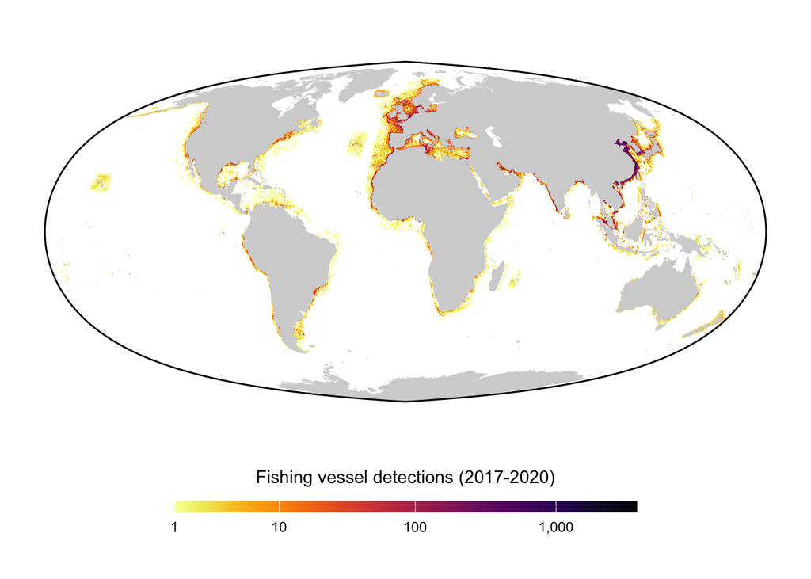

```r
# Set the path to the 2016 folder
#path <- "R/Data/SAR Vessel detections 2017-2020"

# List all CSV files in the folder
#SAR_csv_files <- list.files(path = here::here(path), pattern = "*.csv", full.names = TRUE)

# Read all CSV files and combine them into a single data frame
#SAR_fishing <- SAR_csv_files %>%
#  map_df(~read_csv(.))

# Aggregate fishing hours by latitude and longitude
# Aggregate SAR detections
aggregated_SAR_fishing <- SAR_fishing %>%
  mutate(
    lat_rounded = round(lat, digits = 2),
    lon_rounded = round(lon, digits = 2)
  ) %>%
  group_by(lat_rounded, lon_rounded) %>%
  filter(fishing_score >= 0.9) %>%
  summarise(
    total_presence_score = sum(presence_score, na.rm = TRUE),
    avg_fishing_score = mean(fishing_score, na.rm = TRUE),
    count = n()
  ) %>%
  mutate(total_presence_score = round(total_presence_score, digits = 0)) %>%
  ungroup()

# Standardize to 0.1 degree grid
SAR_data_std <- aggregated_SAR_fishing %>%
  mutate(coords = map2(lon_rounded, lat_rounded, standardize_coords)) %>%
  mutate(
    lon_std = map_dbl(coords, ~ .x$lon_std),
    lat_std = map_dbl(coords, ~ .x$lat_std)
  ) %>%
  group_by(lon_std, lat_std) %>%
  summarise(
    total_presence_score = sum(total_presence_score, na.rm = TRUE),
    count = sum(count, na.rm = TRUE),
    .groups = "drop"
  ) %>%
  # Join overpass frequency data
  left_join(
    overpasses_per_cell %>% dplyr::select(lon_std, lat_std, n_overpasses),
    by = c("lon_std", "lat_std")
  ) %>%
  # Compute normalised detection count
  mutate(
    detections_per_overpass = count / n_overpasses
  )

# Create the world map
world_map <- map_data("world")

# Assign plot to variable
SAR_data_plot <- ggplot() +
  geom_rect(data = project_tiles(SAR_data_std, "total_presence_score"),
            aes(xmin = xmin, xmax = xmax, ymin = ymin, ymax = ymax, fill = total_presence_score)) +
  geom_sf(data = land_projected, fill = "lightgrey", color = "lightgrey", linewidth = 0.1) +
  geom_sf(data = globe_border, fill = NA, color = "black", linewidth = 0.5) +
  scale_fill_viridis(
    option = "inferno",
    direction = -1,
    trans = "log1p",
    name = "Fishing vessel detections (2017-2020)",
    breaks = c(0, 1, 10, 100, 1000, 10000),
    labels = scales::comma,
    guide = guide_colorbar(barwidth = 20, barheight = 0.5, title.position = "top", title.hjust = 0.5)
  ) +
  coord_sf(crs = mcbryde_thomas_2, datum = NA) +
  theme_minimal() +
  labs(title = NULL,
       x = NULL, y = NULL) +
  theme(
    legend.position = "bottom",
    legend.direction = "horizontal",
    legend.box = "vertical",
    legend.margin = ggplot2::margin(t = 20, r = 0, b = 0, l = 0),
    legend.title = element_text(margin = ggplot2::margin(b = 10))
  )
print(SAR_data_plot)
```

```r
# Save the plot
ggsave(here::here("R","Outputs", "SAR_fishing_map.png"),
       plot = SAR_data_plot,
       width = 12,
       height = 8,
       dpi = 300)
```

## Compare AIS, and SAR detection locations

Identifying grid cells with only AIS, only SAR detections or both data types.

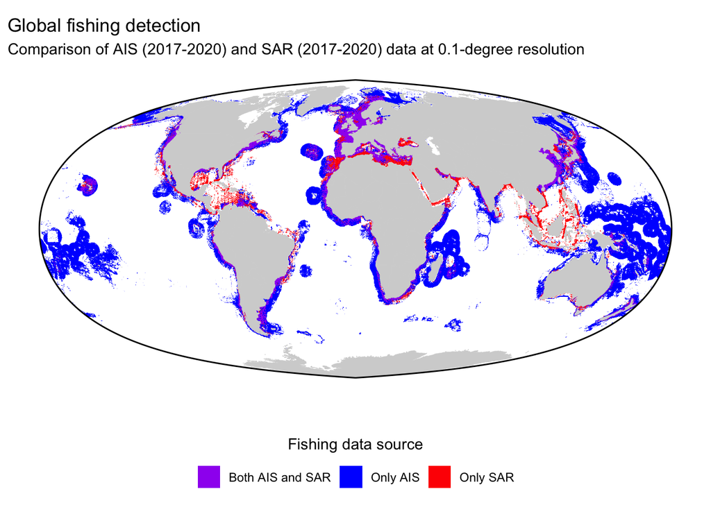

```r
# Merge the datasets
combined_data <- full_join(
  AIS_data_std,
  SAR_data_std,
  by = c("lon_std", "lat_std")
)

# Categorize each cell
combined_data <- combined_data %>%
  mutate(category = case_when(
    total_fishing_hours > 0 & total_presence_score > 0 ~ "Both AIS and SAR",
    total_fishing_hours > 0 & (is.na(total_presence_score) | total_presence_score == 0) ~ "Only AIS",
    (is.na(total_fishing_hours) | total_fishing_hours == 0) & total_presence_score > 0 ~ "Only SAR",
    TRUE ~ "No fishing detected"
  ))

# Create the world map
world_map <- map_data("world")

# Create the plot
world_plot <- ggplot() +
  geom_rect(data = project_tiles(remove_high_seas(combined_data), "category"),
            aes(xmin = xmin, xmax = xmax, ymin = ymin, ymax = ymax, fill = category)) +
  geom_sf(data = land_projected, fill = "lightgrey", color = "lightgrey", linewidth = 0.1) +
  geom_sf(data = globe_border, fill = NA, color = "black", linewidth = 0.5) +
  scale_fill_manual(
    values = c("Both AIS and SAR" = "purple",
               "Only AIS" = "blue",
               "Only SAR" = "red",
               "No fishing detected" = "white"),
    name = "Fishing data source",
    guide = guide_legend(title.position = "top", title.hjust = 0.5)
  ) +
  coord_sf(crs = mcbryde_thomas_2, datum = NA) +
  theme_minimal() +
  labs(title = "Global fishing detection",
       subtitle = "Comparison of AIS (2017-2020) and SAR (2017-2020) data at 0.1-degree resolution",
       x = NULL, y = NULL) +
  theme(
    legend.position = "bottom",
    legend.direction = "horizontal",
    legend.box = "vertical",
    legend.margin = ggplot2::margin(t = 20, r = 0, b = 0, l = 0),
    legend.title = element_text(margin = ggplot2::margin(b = 10))
  )

# Display the plot
print(world_plot)
```

```r
# Save the plot
ggsave(here::here("R","Outputs", "AIS_SAR_comparison_map.png"),
       plot = world_plot,
       width = 12,
       height = 8,
       dpi = 300)

# Get summary statistics
summary_stats <- combined_data %>%
  count(category) %>%
  mutate(percentage = n / sum(n) * 100) %>%
  rename(`Number of cells` = n) %>%
  mutate(percentage = round(percentage, 2))

# Create the table
table_output <- kable(summary_stats,
      format = "html",
      col.names = c("Category", "Number of cells", "Percentage (%)"),
      caption = "Summary statistics of data categories") %>%
  kable_styling(bootstrap_options = c("striped", "hover", "condensed", "responsive"),
                full_width = FALSE,
                position = "center") %>%
  column_spec(2, width = "150px") %>%
  column_spec(3, width = "150px")

table_output
```

Summary statistics of data categories

| Category | Number of cells | Percentage (%) |
| --- | --- | --- |
| Both AIS and SAR | 163095 | 9.12 |
| Only AIS | 1566190 | 87.60 |
| Only SAR | 58668 | 3.28 |

```r
# Save as PNG
save_kable(table_output, file = here::here("R","Outputs","summary_stats_table.png"))
```

## Random forest model

### Data preparation

```r
# Stack the resampled rasters
raster_stack <- stack(Shore_adjusted, Ports_adjusted, Bathy_adjusted)

# Convert the stack to a dataframe
raster_df <- as.data.frame(raster_stack, xy = TRUE)

# Rename the columns
names(raster_df) <- c("x", "y", "dist_shore", "dist_ports", "bathy")

# Remove NA values if desired
raster_df <- na.omit(raster_df)

# Convert to data.table for efficiency
setDT(raster_df)

# Round x and y to 1 decimal place for consistency
raster_df[, `:=`(
  lon_std = round(x, digits = 1),
  lat_std = round(y, digits = 1)
)]

# Keep only ocean areas (negative bathymetry values)
raster_df <- raster_df[bathy < 0]

# Keep the first occurrence of each coordinate pair (because there are duplicates)
raster_df <- unique(raster_df, by = c("lon_std", "lat_std"))
setDT(raster_df)

# Now proceed with the join and model training
#load(here::here("R,"Data","combined_data_O1deg.Rdata"))

# Keep the first occurrence of each coordinate pair (because there are duplicates)
combined_data_01deg <- unique(combined_data_01deg, by = c("lon_std", "lat_std"))
setDT(combined_data_01deg)

# Perform the join using data.table
combined_data_with_rasters <- raster_df[combined_data_01deg,
                                        on = .(lon_std, lat_std),
                                        nomatch = 0]

# Convert back to dataframe if needed
combined_data_with_rasters <- as.data.frame(combined_data_with_rasters)

# Create the new combined dataframe
combined_data_all <- raster_df[, .(lon_std, lat_std, dist_shore, dist_ports, bathy)]

# Perform the join
combined_data_all <- merge(combined_data_all, combined_data_01deg,
                           by = c("lon_std", "lat_std"),
                           all.x = TRUE)

# Fill NA values for has_AIS and has_SAR with FALSE
combined_data_all[is.na(has_AIS), has_AIS := FALSE]
combined_data_all[is.na(has_SAR), has_SAR := FALSE]

# Categorize each cell
combined_data_all <- combined_data_all %>%
  mutate(category = case_when(
    has_AIS == TRUE ~ "AIS Data",
    has_SAR == TRUE ~ "SAR Data Only",
    TRUE ~ "No AIS or SAR Data"
  ))

# Create the world map
world_map <- map_data("world")

# Create the plot
world_plot <- ggplot() +
  geom_map(data = world_map, map = world_map,
           aes(long = long, lat = lat, map_id = region),
           color = "black", fill = "lightgray", size = 0.1) +
  geom_tile(data = combined_data_all,
            aes(x = lon_std, y = lat_std, fill = category, color = category)) +
  scale_fill_manual(
    values = c("AIS Data" = "blue",
               "SAR Data Only" = "red",
               "No AIS or SAR Data" = "black"),
    name = "Data Source",
    guide = guide_legend(title.position = "top", title.hjust = 0.5)
  ) +
  scale_color_manual(
    values = c("AIS Data" = "blue",
               "SAR Data Only" = "red",
               "No AIS or SAR Data" = "black"),
    guide = "none"
  ) +
  coord_fixed(1.3) +
  theme_minimal() +
  labs(title = "Global Data Coverage",
       subtitle = "Distribution of AIS and SAR data at 0.1-degree resolution",
       x = "Longitude", y = "Latitude") +
 theme(
    legend.position = "bottom",
    legend.direction = "horizontal",
    legend.box = "vertical",
    legend.margin = ggplot2::margin(t = 20, r = 0, b = 0, l = 0),
    legend.title = element_text(margin = ggplot2::margin(b = 10)),
    panel.grid.major = element_blank(),
    panel.grid.minor = element_blank(),
    axis.text = element_text(size = 8),
    axis.title = element_text(size = 10),
    plot.title = element_text(size = 14, face = "bold"),
    plot.subtitle = element_text(size = 12)
  )

# Print the plot
#print(world_plot)

# Calculate summary statistics
summary_stats <- combined_data_all[, .(
  data_type = case_when(
    has_AIS == TRUE ~ "AIS Data",
    has_SAR == TRUE ~ "SAR Data Only",
    TRUE ~ "No AIS or SAR Data"
  )
)][, .(
  num_cells = .N,
  percentage = .N / nrow(combined_data_all) * 100
), by = data_type]

# Order the data types
summary_stats <- summary_stats[order(match(data_type, c("AIS Data", "SAR Data Only", "No AIS or SAR Data")))]

# Add total row
total_row <- data.table(
  data_type = "Total",
  num_cells = sum(summary_stats$num_cells),
  percentage = 100
)

summary_stats <- rbindlist(list(summary_stats, total_row))

# Create kable
kable_output <- summary_stats %>%
  kable(
    col.names = c("Data Type", "Number of Cells", "Percentage (%)"),
    digits = c(0, 0, 2),
    align = c("l", "r", "r"),
    caption = "Summary Statistics of Data Types"
  ) %>%
  kable_styling(bootstrap_options = c("striped", "hover", "condensed"), full_width = FALSE) %>%
  row_spec(nrow(summary_stats), bold = TRUE, background = "#F0F0F0") %>%
  footnote(
    general = "AIS Data category includes cells with both AIS and SAR data.",
    general_title = "Note:",
    footnote_as_chunk = TRUE
  )

# Print the kable
#kable_output

# Prepare the training data
#training_data <- combined_data_with_rasters %>%
#  filter(has_AIS & has_SAR) %>%
#  dplyr::select(
#    total_fishing_hours,
#    detections_per_overpass,  # replaced total_presence_score
#    lon_std, lat_std,
#    dist_shore, dist_ports, bathy
#  ) %>%
#  na.omit()
```

### Random forest with normalised SAR detections

```r
# ---- Prepare training data with normalised SAR detections ----
# Keep the first occurrence of each coordinate pair
combined_data_01deg <- unique(combined_data_01deg, by = c("lon_std", "lat_std"))
setDT(combined_data_01deg)

# Perform the join with raster data
combined_data_with_rasters <- raster_df[combined_data_01deg,
                                        on = .(lon_std, lat_std),
                                        nomatch = 0]

# Convert back to dataframe
combined_data_with_rasters <- as.data.frame(combined_data_with_rasters)

# Prepare training data using detections_per_overpass as normalised SAR predictor
training_data <- combined_data_with_rasters %>%
  filter(has_AIS & has_SAR) %>%
  dplyr::select(
    total_fishing_hours,
    detections_per_overpass,
    lon_std, lat_std,
    dist_shore, dist_ports, bathy
  ) %>%
  na.omit() %>%
  mutate(
    log_total_fishing_hours = log10(total_fishing_hours + 1),
    log_detections_per_overpass = log10(detections_per_overpass + 1)
  )

cat("Training data dimensions:", nrow(training_data), "rows,", ncol(training_data), "columns\n")
```

```
Training data dimensions: 114621 rows, 9 columns
```

```r
cat("Missing values in detections_per_overpass:", sum(is.na(training_data$detections_per_overpass)), "\n")
```

```
Missing values in detections_per_overpass: 0
```

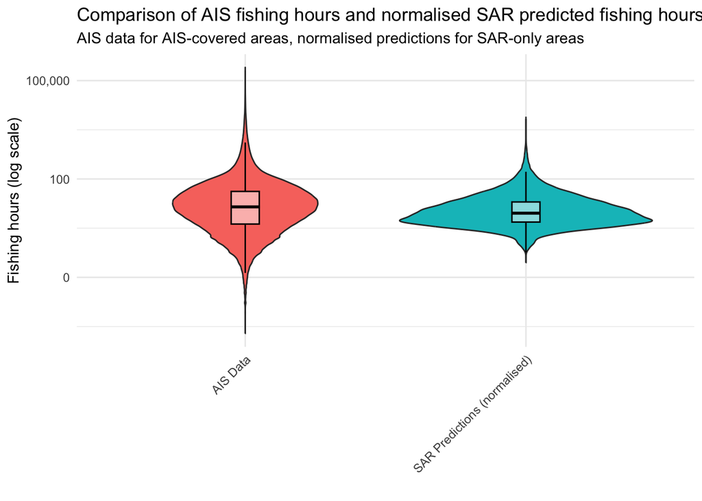

```r
# ---- Train normalised random forest model ----

# No transform
#rf_norm_no_transform <- randomForest(
#  total_fishing_hours ~ detections_per_overpass + lon_std + lat_std +
#    dist_shore + dist_ports + bathy,
#  data = training_data,
#  ntree = 500,
#  importance = TRUE
#)
#saveRDS(rf_norm_no_transform, here::here("R", "Data", "rf_norm_no_transform.rds"))

# Fishing hours log only
#rf_norm_fishing_log <- randomForest(
#  log_total_fishing_hours ~ detections_per_overpass + lon_std + lat_std +
#    dist_shore + dist_ports + bathy,
#  data = training_data,
#  ntree = 500,
#  importance = TRUE
#)
#saveRDS(rf_norm_fishing_log, here::here("R", "Data", "rf_norm_fishing_log.rds"))

# Predictor log only
#rf_norm_predictor_log <- randomForest(
#  total_fishing_hours ~ log_detections_per_overpass + lon_std + lat_std +
#    dist_shore + dist_ports + bathy,
#  data = training_data,
#  ntree = 500,
#  importance = TRUE
#)
#saveRDS(rf_norm_predictor_log, here::here("R", "Data", #"rf_norm_predictor_log.rds"))

# Both log
#rf_norm_both_log <- randomForest(
#  log_total_fishing_hours ~ log_detections_per_overpass + lon_std + lat_std +
#    dist_shore + dist_ports + bathy,
#  data = training_data,
#  ntree = 500,
#  importance = TRUE
#)
#saveRDS(rf_norm_both_log, here::here("R", "Data", "rf_norm_both_log.rds"))

# ---- Evaluate normalised model ----
validation_data <- combined_data_with_rasters %>%
  mutate(
    data_category = case_when(
      has_AIS & has_SAR ~ "Both AIS and SAR",
      has_AIS & !has_SAR ~ "Only AIS",
      !has_AIS & has_SAR ~ "Only SAR",
      TRUE ~ "No fishing detected"
    ),
    log_total_fishing_hours = log10(total_fishing_hours + 1)
  ) %>%
  filter(data_category == "Both AIS and SAR")

results_normalized <- evaluate_model(
  rf_norm_fishing_log,
  validation_data,
  log_target = TRUE
)

# ---- Generate predictions for SAR-only cells ----
prediction_data <- combined_data_with_rasters %>%
  dplyr::select(detections_per_overpass, lon_std, lat_std, dist_shore, dist_ports, bathy)

log_predictions <- predict(rf_norm_fishing_log, newdata = prediction_data)
predictions <- 10^log_predictions - 1

# Add predictions to combined_data_01deg
combined_data_01deg <- combined_data_01deg %>%
  mutate(
    predicted_fishing_hours = case_when(
      has_AIS ~ total_fishing_hours,
      has_SAR ~ predictions[match(
        paste(lon_std, lat_std),
        paste(prediction_data$lon_std, prediction_data$lat_std)
      )],
      TRUE ~ 0
    )
  )

aggregated_data_normalised <- combined_data_01deg %>%
  mutate(
    lon_05deg = floor(lon_std / 0.5) * 0.5,
    lat_05deg = floor(lat_std / 0.5) * 0.5
  ) %>%
  group_by(lon_05deg, lat_05deg) %>%
  summarise(
    predicted_fishing_hours = sum(predicted_fishing_hours, na.rm = TRUE),
    n_cells = n(),
    .groups = "drop"
  )

save(aggregated_data_normalised,
     file = here::here("R", "Data", "Predicted_Fishing_Hours_05Deg_normalised.Rdata"))
# ---- Violin plot: observed vs predicted ----
plot_data <- combined_data_01deg %>%
  mutate(
    ais_fishing_hours = if_else(has_AIS, total_fishing_hours, NA_real_),
    sar_predicted_hours = if_else(!has_AIS & has_SAR, predicted_fishing_hours, NA_real_)
  ) %>%
  dplyr::select(ais_fishing_hours, sar_predicted_hours) %>%
  pivot_longer(cols = c(ais_fishing_hours, sar_predicted_hours),
               names_to = "type",
               values_to = "hours") %>%
  filter(!is.na(hours))

violin_plot <- ggplot(plot_data, aes(x = type, y = hours, fill = type)) +
  geom_violin(trim = FALSE) +
  geom_boxplot(width = 0.1, fill = "white", color = "black",
               alpha = 0.5, outlier.shape = NA) +
  scale_y_log10(labels = scales::comma_format(accuracy = 1)) +
  scale_x_discrete(labels = c("ais_fishing_hours" = "AIS Data",
                               "sar_predicted_hours" = "SAR Predictions (normalised)")) +
  labs(title = "Comparison of AIS fishing hours and normalised SAR predicted fishing hours",
       subtitle = "AIS data for AIS-covered areas, normalised predictions for SAR-only areas",
       x = "", y = "Fishing hours (log scale)", fill = "Type") +
  theme_minimal() +
  theme(legend.position = "none",
        axis.text.x = element_text(angle = 45, hjust = 1))

print(violin_plot)
```

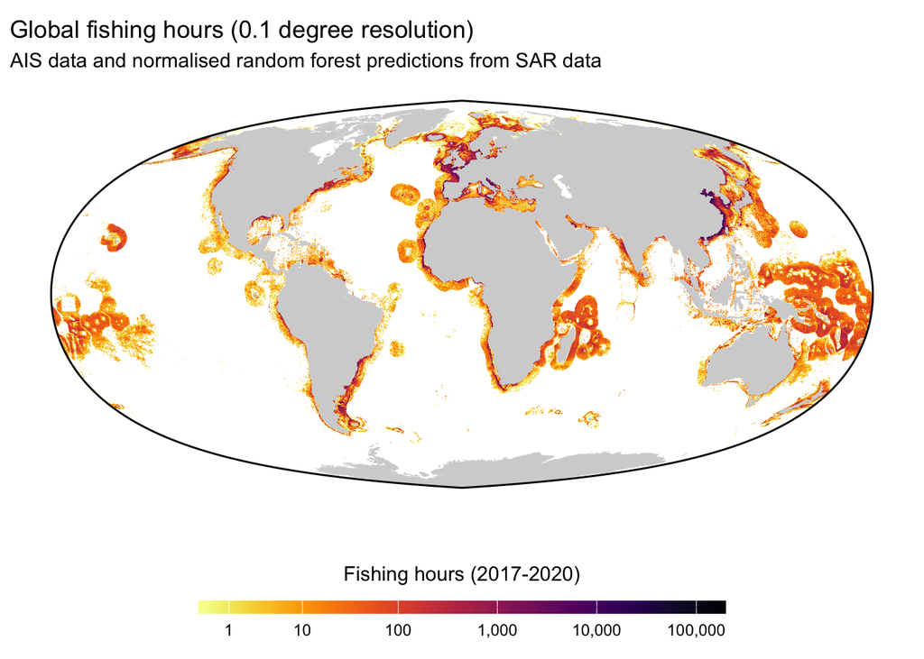

```r
# ---- Maps of predictions ----
world_map <- map_data("world")

# Global map
predicted_plot <- ggplot() +
  geom_rect(data = project_tiles(remove_high_seas(combined_data_01deg), "predicted_fishing_hours"),
            aes(xmin = xmin, xmax = xmax, ymin = ymin, ymax = ymax, fill = predicted_fishing_hours)) +
  geom_sf(data = land_projected, fill = "lightgrey", color = "lightgrey", linewidth = 0.1) +
  geom_sf(data = globe_border, fill = NA, color = "black", linewidth = 0.5) +
  scale_fill_viridis(
    option = "inferno",
    direction = -1,
    trans = "log1p",
    name = "Fishing hours (2017-2020)",
    breaks = c(0, 1, 10, 100, 1000, 10000, 100000, 1000000),
    labels = scales::comma,
    guide = guide_colorbar(barwidth = 20, barheight = 0.5,
                           title.position = "top", title.hjust = 0.5)
  ) +
  coord_sf(crs = mcbryde_thomas_2, datum = NA) +
  theme_minimal() +
  labs(title = "Global fishing hours (0.1 degree resolution)",
       subtitle = "AIS data and normalised random forest predictions from SAR data",
       x = NULL, y = NULL) +
  theme(
    legend.position = "bottom",
    legend.direction = "horizontal",
    legend.box = "vertical",
    legend.margin = ggplot2::margin(t = 20, r = 0, b = 0, l = 0),
    legend.title = element_text(margin = ggplot2::margin(b = 10))
  )

print(predicted_plot)
```

```r
ggsave(here::here("R", "Outputs", "predicted_plot_SAR_normalized.png"),
       plot = predicted_plot,
       width = 12, height = 8, dpi = 300)
```

### Comparison of transformations - normalised models

```r
validation_data_norm <- combined_data_with_rasters %>%
  mutate(
    data_category = case_when(
      has_AIS & has_SAR ~ "Both AIS and SAR",
      has_AIS & !has_SAR ~ "Only AIS",
      !has_AIS & has_SAR ~ "Only SAR",
      TRUE ~ "No fishing detected"
    )
  ) %>%
  filter(data_category == "Both AIS and SAR") %>%
  mutate(
    log_detections_per_overpass = log10(detections_per_overpass + 1),
    log_total_fishing_hours = log10(total_fishing_hours + 1)
  )

results_norm_no_transform <- evaluate_model(rf_norm_no_transform, validation_data_norm)
results_norm_fishing_log <- evaluate_model(rf_norm_fishing_log, validation_data_norm, log_target = TRUE)
results_norm_predictor_log <- evaluate_model(rf_norm_predictor_log, validation_data_norm)
results_norm_both_log <- evaluate_model(rf_norm_both_log, validation_data_norm, log_target = TRUE)

results_comparison <- data.frame(
  Metric = c(
    "Mean absolute error", "Root mean squared error",
    "Mean absolute percentage error", "Median absolute error",
    "R-squared", "Adjusted R-squared",
    "Mean of residuals", "Standard deviation of residuals"
  ),
  No_Transform = round(c(
    results_norm_no_transform$`Mean absolute error`,
    results_norm_no_transform$`Root mean squared error`,
    results_norm_no_transform$`Mean absolute percentage error`,
    results_norm_no_transform$`Median absolute error`,
    results_norm_no_transform$`R-squared`,
    results_norm_no_transform$`Adjusted R-squared`,
    results_norm_no_transform$`Mean of residuals`,
    results_norm_no_transform$`Standard deviation of residuals`
  ), 2),
  Fishing_Log = round(c(
    results_norm_fishing_log$`Mean absolute error`,
    results_norm_fishing_log$`Root mean squared error`,
    results_norm_fishing_log$`Mean absolute percentage error`,
    results_norm_fishing_log$`Median absolute error`,
    results_norm_fishing_log$`R-squared`,
    results_norm_fishing_log$`Adjusted R-squared`,
    results_norm_fishing_log$`Mean of residuals`,
    results_norm_fishing_log$`Standard deviation of residuals`
  ), 2),
  Predictor_Log = round(c(
    results_norm_predictor_log$`Mean absolute error`,
    results_norm_predictor_log$`Root mean squared error`,
    results_norm_predictor_log$`Mean absolute percentage error`,
    results_norm_predictor_log$`Median absolute error`,
    results_norm_predictor_log$`R-squared`,
    results_norm_predictor_log$`Adjusted R-squared`,
    results_norm_predictor_log$`Mean of residuals`,
    results_norm_predictor_log$`Standard deviation of residuals`
  ), 2),
  Both_Log = round(c(
    results_norm_both_log$`Mean absolute error`,
    results_norm_both_log$`Root mean squared error`,
    results_norm_both_log$`Mean absolute percentage error`,
    results_norm_both_log$`Median absolute error`,
    results_norm_both_log$`R-squared`,
    results_norm_both_log$`Adjusted R-squared`,
    results_norm_both_log$`Mean of residuals`,
    results_norm_both_log$`Standard deviation of residuals`
  ), 2)
)

kable(results_comparison, format = "html", digits = 2,
      col.names = c("Metric", "No transform", "Fishing hours log",
                    "Predictor log", "Both log"),
      caption = "Model performance comparison - normalised SAR detections per overpass") %>%
  kable_styling(bootstrap_options = c("striped", "hover", "condensed", "responsive"),
                full_width = FALSE) %>%
  add_header_above(c(" " = 1, "Models" = 4)) %>%
  column_spec(1, bold = TRUE)
```

Model performance comparison - normalised SAR detections per overpass

| Metric | Models No transform | Models Fishing hours log | Models Predictor log | Models Both log |
| --- | --- | --- | --- | --- |
| Mean absolute error | 206.62 | 242.98 | 206.90 | 244.17 |
| Root mean squared error | 910.60 | 1413.36 | 915.74 | 1415.23 |
| Mean absolute percentage error | 1783.91 | 85.64 | 1779.14 | 86.25 |
| Median absolute error | 32.69 | 11.70 | 32.71 | 11.71 |
| R-squared | 0.71 | 0.77 | 0.71 | 0.77 |
| Adjusted R-squared | 0.71 | 0.77 | 0.71 | 0.77 |
| Mean of residuals | -6.39 | 208.95 | -6.26 | 209.94 |
| Standard deviation of residuals | 910.58 | 1397.83 | 915.72 | 1399.58 |

#### Interpretation of model comparison metrics

Four model variants were compared to identify the optimal transformation strategy for normalised SAR detections per overpass. The results clearly favour log-transforming the response variable (fishing hours).

The fishing hours log model (log_total_fishing_hours ~ detections_per_overpass) is selected as the final model. It performs marginally better than the both-log variant on MAPE (85.64% vs 86.25%) and RMSE (1413 vs 1415), and is simpler to interpret since the predictor remains on its original scale.

Compared to the previous non-normalised model (R-squared = 0.82, MAPE = 69.71%), performance is slightly reduced. This is expected: normalisation by overpass frequency removes a spurious signal that the original model was exploiting, namely systematic variation in detection counts driven by uneven satellite coverage rather than true differences in fishing intensity. The normalised model is therefore preferred on methodological grounds despite the modest reduction in predictive accuracy.

### Selected Model performance

```r
validation_data <- combined_data_with_rasters %>%
  mutate(
    data_category = case_when(
      has_AIS & has_SAR ~ "Both AIS and SAR",
      has_AIS & !has_SAR ~ "Only AIS",
      !has_AIS & has_SAR ~ "Only SAR",
      TRUE ~ "No fishing detected"
    ),
    log_total_fishing_hours = log10(total_fishing_hours + 1)
  )

# Evaluate the model
validation_data <- validation_data %>% filter(data_category == "Both AIS and SAR")
results_rf_fishing_log <- evaluate_model(rf_norm_fishing_log, validation_data, log_target = TRUE)

# Create a dataframe for the table
results_table <- data.frame(
  Metric = c("Mean absolute error", "Root mean squared error", "Mean absolute percentage error",
             "Median absolute error", "R-squared", "Adjusted R-squared",
             "Mean of residuals", "Standard deviation of residuals"),
  Value = round(c(results_rf_fishing_log$`Mean absolute error`,
                  results_rf_fishing_log$`Root mean squared error`,
                  results_rf_fishing_log$`Mean absolute percentage error`,
                  results_rf_fishing_log$`Median absolute error`,  # FIXED: was "Median ebsolute error"
                  results_rf_fishing_log$`R-squared`,
                  results_rf_fishing_log$`Adjusted R-squared`,  # FIXED: was "Adjusted r-squared"
                  results_rf_fishing_log$`Mean of residuals`,
                  results_rf_fishing_log$`Standard deviation of residuals`),
                2))

table_output <- kable(results_table, format = "html", digits = 4,
      caption = "Model evaluation metrics for log-transformed fishing hours model") %>%
  kable_styling(bootstrap_options = c("striped", "hover", "condensed", "responsive"),
                full_width = TRUE,
                position = "center")

table_output
```

Model evaluation metrics for log-transformed fishing hours model

| Metric | Value |
| --- | --- |
| Mean absolute error | 242.98 |
| Root mean squared error | 1413.36 |
| Mean absolute percentage error | 85.64 |
| Median absolute error | 11.70 |
| R-squared | 0.77 |
| Adjusted R-squared | 0.77 |
| Mean of residuals | 208.95 |
| Standard deviation of residuals | 1397.83 |

```r
# Save as HTML first
save_kable(table_output, file = here::here("R", "Outputs", "model_evaluation.html"))

# Then screenshot with custom viewport
invisible(webshot(here::here("R", "Outputs", "model_evaluation.html"),
        here::here("R", "Outputs", "model_evaluation.png"),
        vwidth = 800,   # Width in pixels
        vheight = 360,  # Height in pixels - adjust as needed
        zoom = 2))

# For feature importance, create a separate table
# Use $ before the backticks
feature_importance <- as.data.frame(results_rf_fishing_log$`Feature importance`)
feature_importance$Feature <- rownames(feature_importance)
feature_importance <- feature_importance[, c("Feature", "%IncMSE", "IncNodePurity")]
colnames(feature_importance) <- c("Feature", "%IncMSE", "IncNodePurity")

# Sort the feature importance table by %IncMSE in descending order
feature_importance <- feature_importance[order(-feature_importance$`%IncMSE`), ]

# Create the table
table_output <- kable(feature_importance, format = "html", digits = 2,
      col.names = c("Feature", "%IncMSE", "IncNodePurity"),
      caption = "Feature importance for log-transformed fishing hours model") %>%
  kable_styling(bootstrap_options = c("striped", "hover", "condensed", "responsive"),
                full_width = TRUE, position = "center") %>%
  column_spec(1, bold = TRUE) %>%
  column_spec(2:3, width = "150px")

table_output
```

Feature importance for log-transformed fishing hours model

|  | Feature | %IncMSE | IncNodePurity |
| --- | --- | --- | --- |
| lat_std | lat_std | 245.02 | 18205.72 |
| lon_std | lon_std | 237.03 | 21063.02 |
| bathy | bathy | 233.48 | 24608.87 |
| detections_per_overpass | detections_per_overpass | 173.69 | 16876.90 |
| dist_shore | dist_shore | 113.17 | 10280.72 |
| dist_ports | dist_ports | 109.59 | 12758.55 |

```r
# Save as HTML first
save_kable(table_output, file = here::here("R", "Outputs", "feature_importance.html"))

# Then screenshot with custom viewport
invisible(webshot(here::here("R", "Outputs", "feature_importance.html"),
        here::here("R", "Outputs", "feature_importance.png"),
        vwidth = 720,   # Width in pixels
        vheight = 300,  # Height in pixels - adjust as needed
        zoom = 2))
```

## Maps of predictions

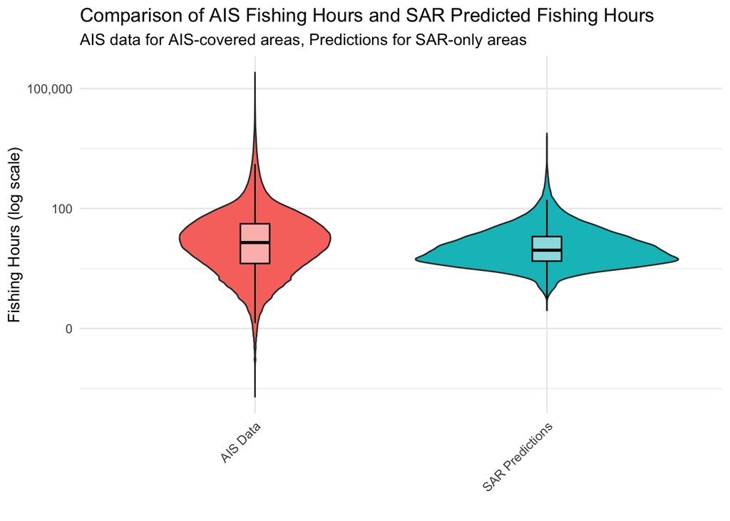

```r
# Prepare the prediction data
prediction_data <- combined_data_with_rasters %>%
  dplyr::select(
    detections_per_overpass,  # replaced total_presence_score
    lon_std, lat_std,
    dist_shore, dist_ports, bathy
  )

# Make predictions
log_predictions <- predict(rf_norm_fishing_log, newdata = prediction_data)

# Back-transform predictions
predictions <- 10^log_predictions - 1

# Add predictions to the original dataset
combined_data_01deg <- combined_data_01deg %>%
  mutate(
    predicted_fishing_hours = case_when(
      has_AIS ~ total_fishing_hours,
      has_SAR ~ predictions[match(paste(lon_std, lat_std), paste(prediction_data$lon_std, prediction_data$lat_std))],
      TRUE ~ 0
    )
  )

#Violin plot of observed versus predicted fishing hours
# Prepare data for plotting
plot_data <- combined_data_01deg %>%
  mutate(
    ais_fishing_hours = if_else(has_AIS, total_fishing_hours, NA_real_),
    sar_predicted_hours = if_else(!has_AIS & has_SAR, predicted_fishing_hours, NA_real_)
  ) %>%
  dplyr::select(ais_fishing_hours, sar_predicted_hours) %>%
  pivot_longer(cols = c(ais_fishing_hours, sar_predicted_hours),
               names_to = "type",
               values_to = "hours") %>%
  filter(!is.na(hours))

# Create violin plot
violin_plot <- ggplot(plot_data, aes(x = type, y = hours, fill = type)) +
  geom_violin(trim = FALSE) +
  geom_boxplot(width = 0.1, fill = "white", color = "black", alpha = 0.5, outlier.shape = NA) +
  scale_y_log10(labels = scales::comma_format(accuracy = 1)) +
  scale_x_discrete(labels = c("ais_fishing_hours" = "AIS Data",
                              "sar_predicted_hours" = "SAR Predictions")) +
  labs(title = "Comparison of AIS Fishing Hours and SAR Predicted Fishing Hours",
       subtitle = "AIS data for AIS-covered areas, Predictions for SAR-only areas",
       x = "",
       y = "Fishing Hours (log scale)",
       fill = "Type") +
  theme_minimal() +
  theme(legend.position = "none",
        axis.text.x = element_text(angle = 45, hjust = 1))

# Print the plot
print(violin_plot)
```

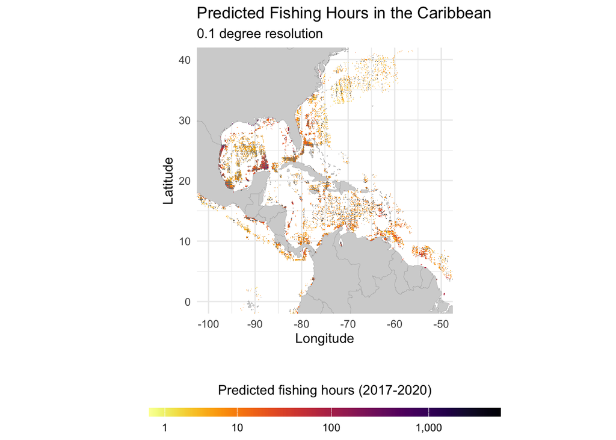

```r
# Map of predicted fishing hours only
# Prepare the data for the map
map_data <- combined_data_01deg %>%
  filter(!has_AIS & has_SAR) %>%
  dplyr::select(lon_std, lat_std, predicted_fishing_hours)

# The map_data now contains back-transformed predictions, so no further transformation is needed

#predicted_SAR_only_1RF=map_data
#save(predicted_SAR_only_1RF, file="predicted_SAR_only_1RF.Rdata")

# Create the world map
world_map <- map_data("world")

# Function to create map for a specific region
create_region_map <- function(data, world_map, lon_col, lat_col, lon_range, lat_range, title, subtitle) {
  ggplot() +
    geom_map(data = world_map, map = world_map,
             aes(long, lat, map_id = region),
             color = "darkgray", fill = "lightgray", size = 0.1) +
    geom_tile(data = data,
              aes(x = .data[[lon_col]], y = .data[[lat_col]], fill = predicted_fishing_hours)) +
    scale_fill_viridis(
      option = "inferno",
      direction = -1,
      trans = "log1p",
      name = "Predicted fishing hours (2017-2020)",
      breaks = c(0, 1, 10, 100, 1000, 10000, 100000, 1000000),
      labels = scales::comma,
      guide = guide_colorbar(barwidth = 20, barheight = 0.5, title.position = "top", title.hjust = 0.5)
    ) +
    coord_fixed(1.3, xlim = lon_range, ylim = lat_range) +
    theme_minimal() +
    labs(title = title,
         subtitle = subtitle,
         x = "Longitude", y = "Latitude") +
    theme(
      legend.position = "bottom",
      legend.direction = "horizontal",
      legend.box = "vertical",
      legend.margin = ggplot2::margin(t = 20, r = 0, b = 0, l = 0),
      legend.title = element_text(margin = ggplot2::margin(b = 10))
    )
}

# Global map
predicted_SAR_only_plot <- create_region_map(map_data, world_map, "lon_std", "lat_std", c(-180, 180), c(-90, 90), "Predicted Fishing Hours in Areas with Only SAR Detections", "0.1 degree resolution")

# Caribbean map
caribbean_map <- create_region_map(map_data, world_map, "lon_std", "lat_std", c(-100, -50), c(0, 40), "Predicted Fishing Hours in the Caribbean", "0.1 degree resolution")

# Northwestern Indian Ocean to Western European waters map
indian_european_map <- create_region_map(map_data, world_map, "lon_std", "lat_std", c(-20, 80), c(0, 70), "Predicted Fishing Hours from Northern Indian Ocean \nto Eastern Atlantic", "0.1 degree resolution")

# Asia map
asia_map <- create_region_map(map_data, world_map, "lon_std", "lat_std", c(60, 180), c(-20, 60), "Predicted Fishing Hours in Asia", "0.1 degree resolution")

# Print the maps
#print(predicted_SAR_only_plot)
print(caribbean_map)
```

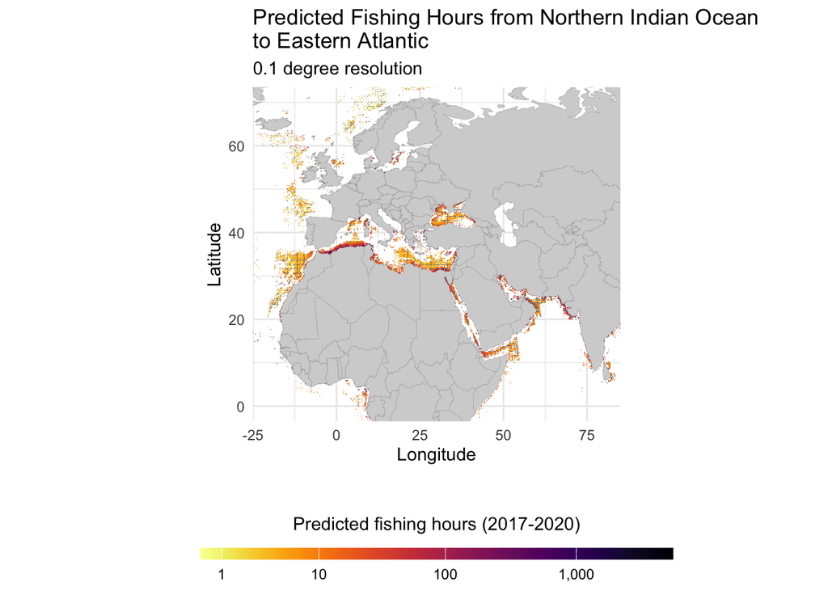

```r
print(indian_european_map)
```

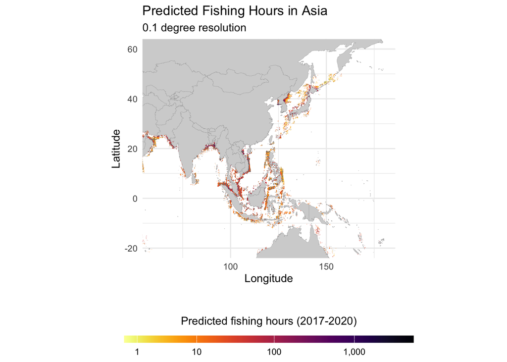

```r
print(asia_map)
```

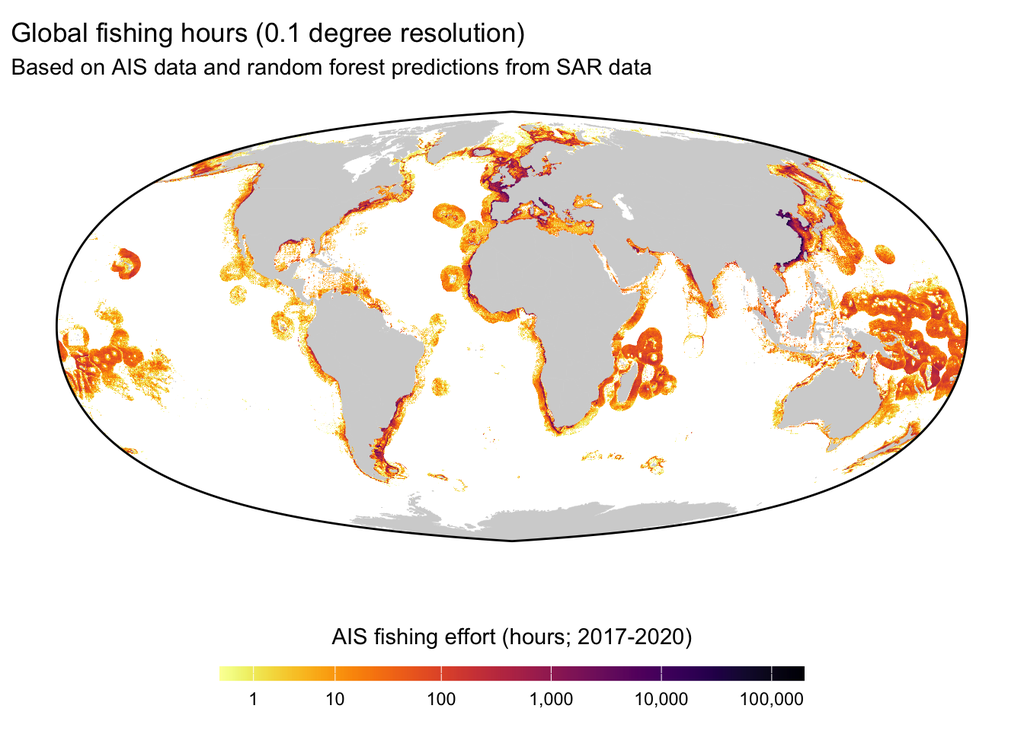

```r
#Map of both original and predicted AIS fishing hours
# Visualize the results
predicted_plot <- ggplot() +
  geom_rect(data = project_tiles(remove_high_seas(combined_data_01deg), "predicted_fishing_hours"),
            aes(xmin = xmin, xmax = xmax, ymin = ymin, ymax = ymax, fill = predicted_fishing_hours)) +
  geom_sf(data = land_projected, fill = "lightgrey", color = "lightgrey", linewidth = 0.1) +
  geom_sf(data = globe_border, fill = NA, color = "black", linewidth = 0.5) +
  scale_fill_viridis(
    option = "inferno",
    direction = -1,
    trans = "log1p",
    name = "AIS fishing effort (hours; 2017-2020)",
    breaks = c(0, 1, 10, 100, 1000, 10000, 100000, 1000000),
    labels = scales::comma,
    guide = guide_colorbar(barwidth = 20, barheight = 0.5, title.position = "top", title.hjust = 0.5)
  ) +
  coord_sf(crs = mcbryde_thomas_2, datum = NA) +
  theme_minimal() +
  labs(title = "Global fishing hours (0.1 degree resolution)",
       subtitle = "Based on AIS data and random forest predictions from SAR data",
       x = NULL, y = NULL) +
  theme(
    legend.position = "bottom",
    legend.direction = "horizontal",
    legend.box = "vertical",
    legend.margin = ggplot2::margin(t = 20, r = 0, b = 0, l = 0),
    legend.title = element_text(margin = ggplot2::margin(b = 10))
  )

print(predicted_plot)
```

```r
# Save the plot
ggsave(here::here("R", "Outputs", "predicted_plot_SAR_only.png"),
       plot = predicted_plot,
       width = 12,
       height = 8,
       dpi = 300)
```